# PSY 5939: Longitudinal Data Analysis

# 1 Two observations

# 1.1 Two observations

# 1.1.1 Basic models for 2 observations per unit

True longitudinal data has 3 or more observations per unit  
You need at least 3 observations per unit for both mixed models and latent growth models

But sometimes you just don’t have 3 observations

- Someone else’s data (your advisor’s, public data, etc.)
- Poor planning on your part :(

There **are** some basic models based on ANOVA and regression that can be used when you have just 2 observations per unit

# 1.1.2 3 observations per unit

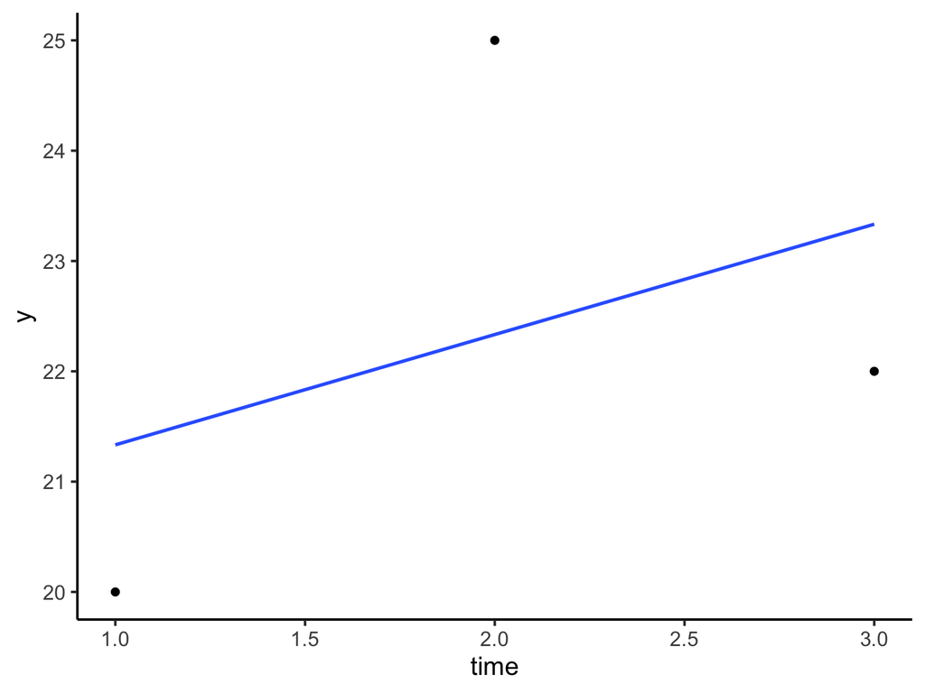

# 1.1.3 2 observations per unit

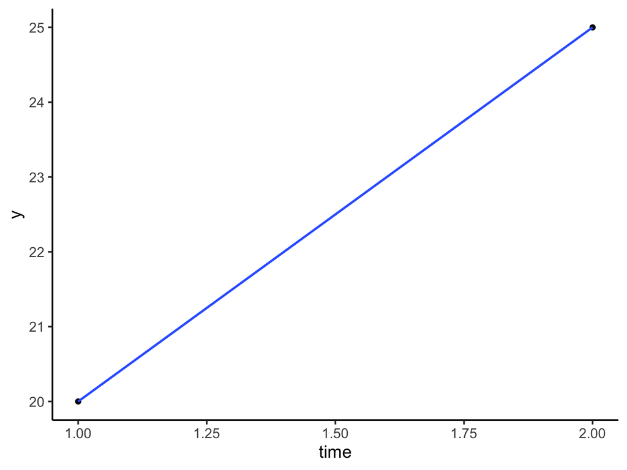

# 1.1.4 Types of analysis

- Difference scores (also called “change scores”)
- Partial change scores (also called “residualized change scores”)
- Analysis of covariance

These are **different analyses**, so they **may give different results**

- Shocking!

The analyses themselves are quite simple

We’ll focus on how each method handles change (or does not) and how the nuanced differences between methods lead to different results

# 2 Difference scores

# 2.1 Difference scores

# 2.1.1 Difference scores

For longitudinal data, a difference score is the **difference** between scores on a variable at two time points

$Y_{2-1} = Y_2 - Y_1$

Typical to subtract time 1 from time 2

- **Positive** values indicate an **increase** over time

Difference scores should not be standardized in any way

# 2.1.2 Difference score models

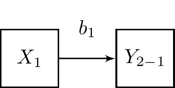

How does $X$ (at time 1) predict change in $Y$?

$\hat{Y}_{2-1} = b_0 + b_1 X_1$

# 2.1.3 Difference score models

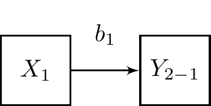

$b_0$ is the intercept

- Expected value of $Y_{2-1}$ when $X_1$ equals 0
- Expected **change** in $Y$ when $X_1$ equals 0

$b_1$ is the slope

- Increase in $Y_{2-1}$ for a 1 unit increase in $X_1$
- Expected change in **change** in $Y$ for a 1 unit increase in $X_1$

# 2.2 Fixed regression analysis of change

# 2.2.1 Fixed regression analysis of change

An expansion on the basic difference score model – Allison (2005)

Use the difference score for the predictor too

$\hat{Y}_{2-1} = b_0 + b_1 X_{2-1}$

Does **change** in $X$ predict **change** in $Y$?

Later in the semester, we’ll talk about “time varying predictors”

- This is the simplest version of time varying predictors

# 2.2.2 Fixed regression analysis of change

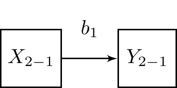

How does **change** in $X$ from time 1 to 2 predict **change** in $Y$ from time 1 to 2?

$\hat{Y}_{2-1} = b_0 + b_1 X_{2-1}$

# 2.2.3 Fixed regression analysis of change

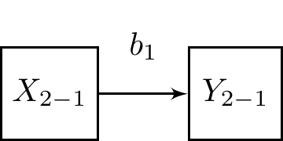

$b_0$ is the intercept

- Expected value of $Y_{2-1}$ when $X_{2-1}$ equals 0
- Expected change in $Y$ for someone who doesn’t change on $X$

$b_1$ is the slope

- Increase in $Y_{2-1}$ for a 1 unit change in $X_{2-1}$
- Expected change in **change** in $Y$ for a 1 unit change in **change** in $X$

# 2.3 Summary

# 2.3.1 Summary of difference score models

**Difference score regression**

Difference score as outcome

$\hat{Y}_{2-1} = b_0 + b_1 X_1$

**Fixed regression analysis of change**

Difference score as outcome

Difference score as predictor

$\hat{Y}_{2-1} = b_0 + b_1 X_{2-1}$

# 3 Partial change scores

# 3.1 Correlation and partial correlation

# 3.1.1 Correlations with difference scores

The idea behind difference scores is that you remove the influence of the individual timepoints and examine only change

The problem: $Y_1$ is always correlated with $Y_{2-1}$

- Difference score doesn’t remove all the influence of time 1

The question: How to get a difference score that **removes all the influence of time 1**?

The answer: Look more carefully at **correlations**, specifically **partial correlations**

# 3.1.2 Correlation

Degree of association between two variables

Proportion of overlap

The correlation between $X$ and $Y$

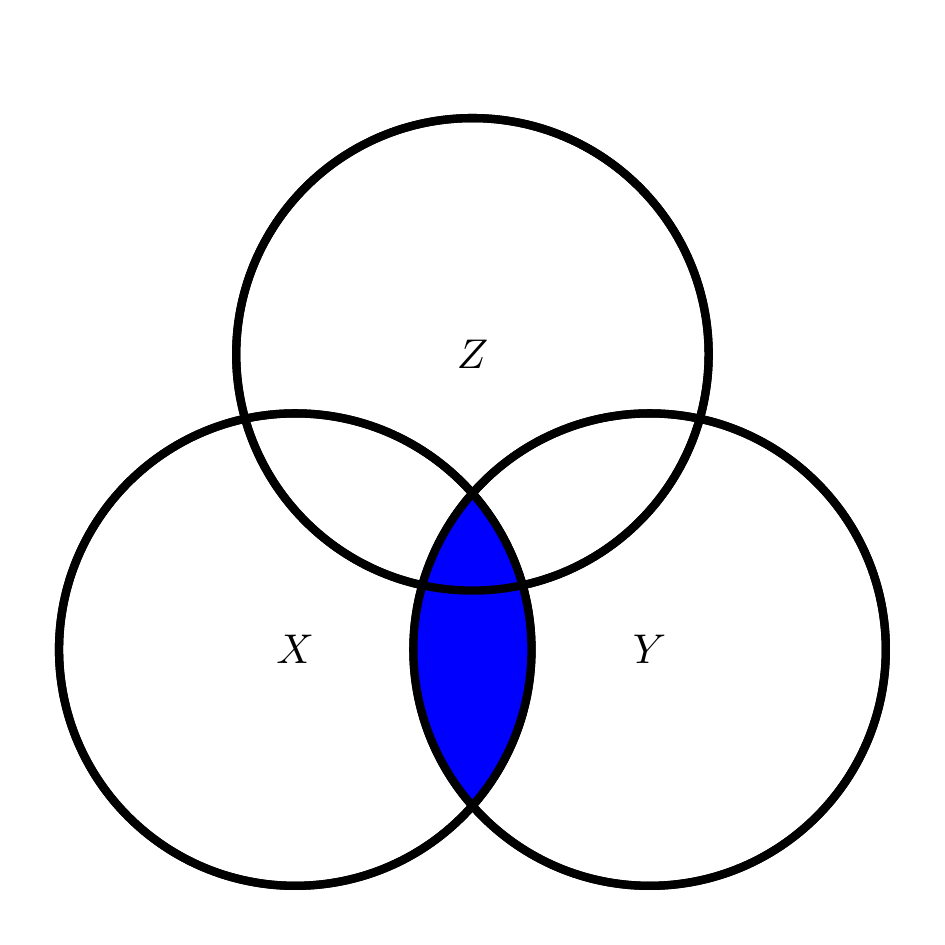

# 3.1.3 Partial correlation

Degree of association between two variables, with the effect of other variables **removed**

Shaded section is the relationship between $X$ and $Y$, partially out the effect of $Z$

(Like a partial regression coefficient)

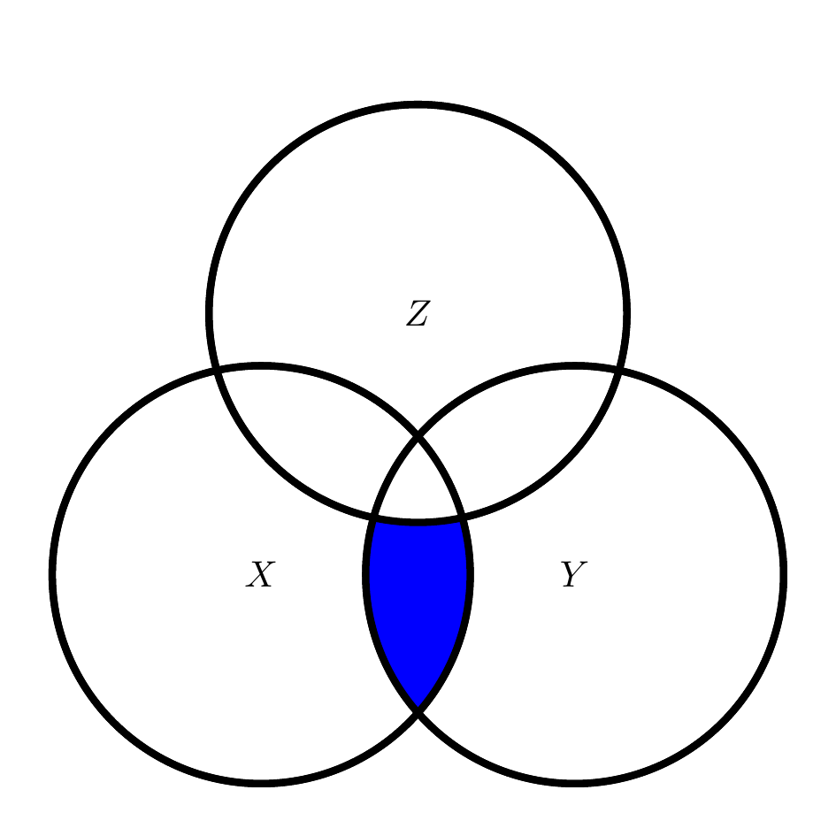

# 3.2 Partial change score

# 3.2.1 Partial change score

Use partial correlations to create a difference score that’s uncorrelated with time 1

- Specifically, we will use regressions to get partial regression coefficients

Also called “regressed change score”

Cohen, Cohen, West, & Aiken (2003), page 570

3 steps

1. How much does $Y_1$ relate to $Y_2$?
2. Remove that part from $Y_2$
3. Use that new variable as the outcome

# 3.2.2 Step 1: Regress $Y_2$ on $Y_1$

$\hat{Y}_2 = b_0 + b_{Y_2Y_1} Y_1$

$b_{Y_2Y_1}$ is the relationship between $Y_1$ and $Y_2$

- Typically, this is **positive** and **relatively large**

# 3.2.3 Step 2: Remove the part of $Y_1$ that’s related to $Y_2$ from $Y_2$

$b_{Y_2Y_1}$ reflects the portion of $Y_1$ that’s related to $Y_2$

Subtract $b_{Y_2Y_1} \times Y_1$ from $Y_2$

New quantity:

$Y_2 - (b_{Y_2Y_1} \times Y_1)$

- $Y_2$ with all time 1 influence removed

[Note: Imagine that we used 1 instead of $b_{Y_2Y_1}$ here. That would be the same as the difference score. More on that later.]

# 3.2.4 Step 3: Use $Y_2 - (b_{Y_2Y_1} \times Y_1)$ as your outcome

The new outcome variable is $Y_2 - (b_{Y_2Y_1} \times Y_1)$

- I’ll call it $newY$

Regress $newY$ on predictor(s):

$\hat{newY}= b_0 + b_1 X_1$

$b_1$ is the effect of $X$ **on the part of $Y_2$ that’s unrelated to $Y_1$**

- The part of $Y$ that has **changed** from time 1 to time 2
- $b_1$ is the relationship between $X$ and the **change** in $Y$

# 3.2.5 Summary of partial change scores

Literally remove the part of $Y_2$ that is related to $Y_1$

- Then predict what’s left over

The part of $Y_2$ that isn’t related to $Y_1$ is the part of $Y$ that **changes**

- You’re predicting change in $Y$

# 4 Analysis of covariance

# 4.1 ANCOVA and covariates

# 4.1.1 Analysis of covariance (ANCOVA)

Strictly speaking, ANCOVA refers to:

- A relationship between two variables
- A third variable is included as a **covariate**
- Covariate is related to the outcome but not the predictor(s)

There are a number of assumptions of the ANCOVA model

(Note that I’m going to talk about this as a *regression model* rather than the traditional ANOVA approach, but they’re the same thing because ANOVA is just a special type of regression)

# 4.1.2 ANCOVA model

$\hat{Y} = b_0 + b_1 X + b_2 C$

We are interested in the relationship between $X$ and $Y$

But we are concerned that the relationship between $C$ and $Y$ could distort the $X-Y$ relationship

# 4.1.3 What ANCOVA looks like

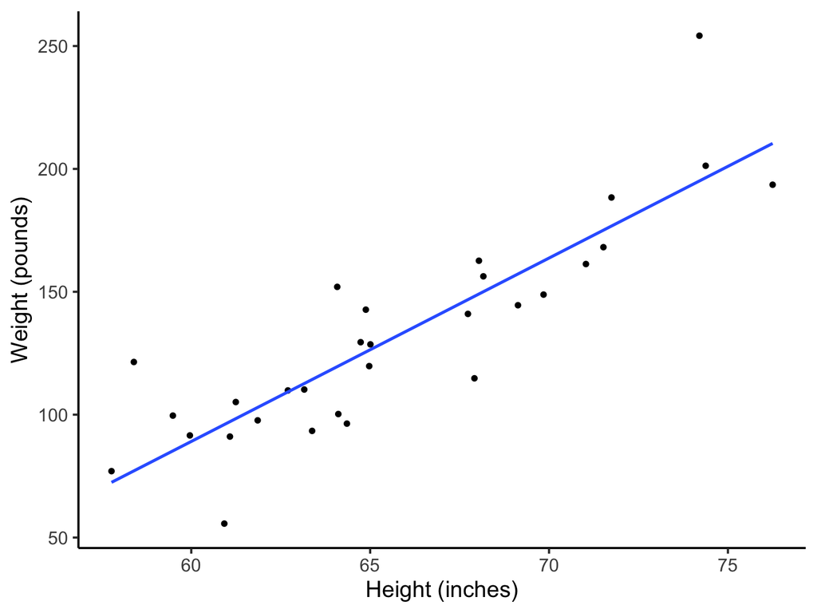

# 4.1.4 What ANCOVA looks like

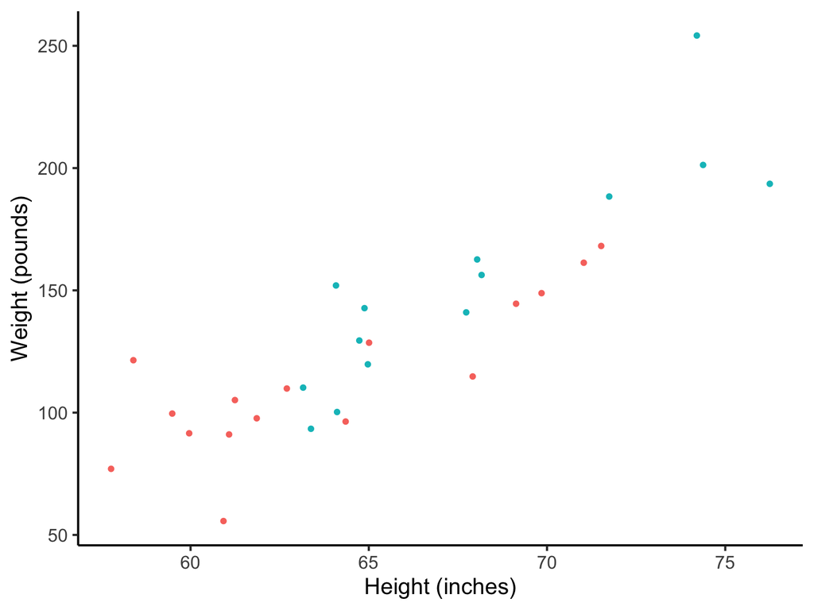

# 4.1.5 What ANCOVA looks like

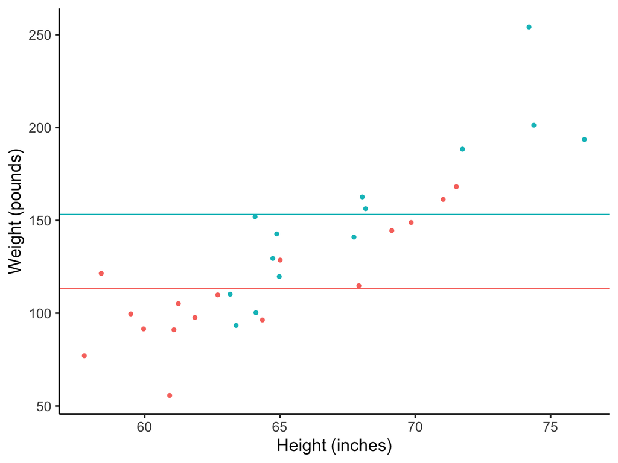

# 4.1.6 What ANCOVA looks like

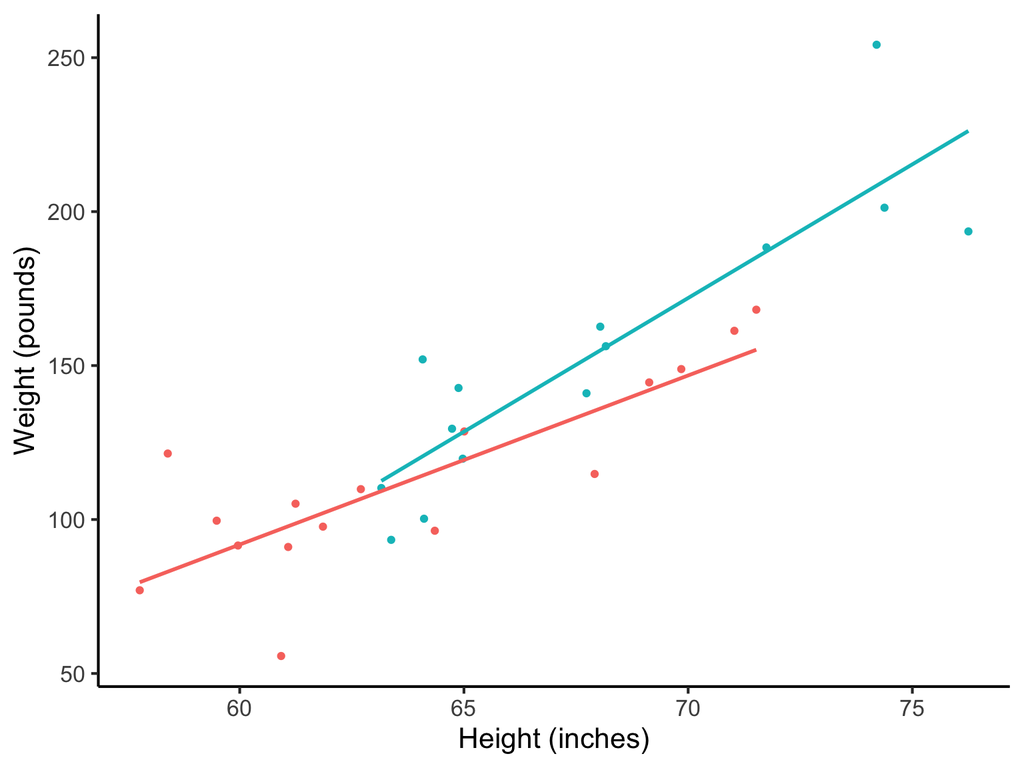

# 4.2 Assumptions

# 4.2.1 Assumptions of ANCOVA

Under classic ANCOVA assumptions include:

- Homogeneity of variance
  - Same residual variance for each group
- Homogeneity of slopes
  - No interaction between predictor and covariate
- Covariate related to outcome but not predictor

In this example, the slopes for males and females were not exactly the same and the covariate (gender) was related to both height and weight (not just the outcome)

# 4.3 ANCOVA for longitudinal data

# 4.3.1 Analysis of covariance, more generally

When used with multiple waves of data, these more general ANCOVA-type modelse are also called lagged regression, autoregression, baseline adjusted regression

The covariate is a **baseline or time 1** measure of the outcome

When you include a covariate, you are saying that the effects of other variables are “holding the covariate equal”

- In other words, you’re equating people on the baseline measure
- This model says, if everyone were the same at time 1, what is the relationship between $X$ and $Y$?

# 4.3.2 Prospective model

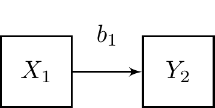

$\hat{Y}_2 = b_0 + b_1 X_1$

How does $X$ at time 1 predict $Y$ at time 2?

No *change* in this model since each variable is only measured once

# 4.3.3 ANCOVA for two waves

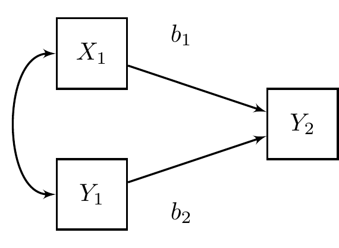

$\hat{Y}_2 = b_0 + b_1 X_1 + b_2 Y_1$

How does $X$ at time 1 predict $Y$ at time 2, controlling for $Y$ at time 1?

# 4.3.4 ANCOVA for two waves

$\hat{Y}_2 = b_0 + b_1 X_1 + b_2 Y_1$

Two slightly different but **equally valid** ways to think about it

**ANCOVA way**:

$b_1$ coefficient reflects the effect of $X$ at time 1 on $Y$ at time 2, assuming that everyone is the same on $Y$ at time 1

**Partial regression coefficient way**:

$b_2$ coefficient reflects the stability of the $Y$ construct over time

$b_1$ coefficient reflects what $X_1$ is able to predict about $Y_2$, after accounting for that stability

- $b_1$ coefficient reflects what $X$ can predict about **change** in $Y$

# 4.3.5 ANCOVA figure

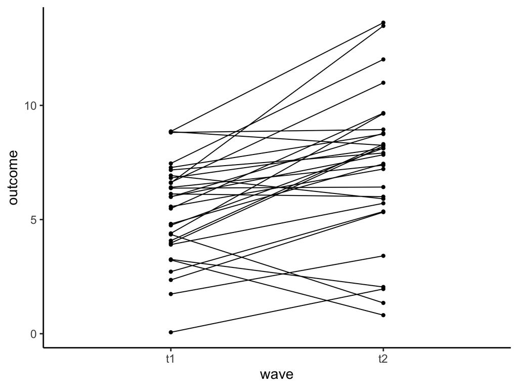

# 4.3.6 ANCOVA figure

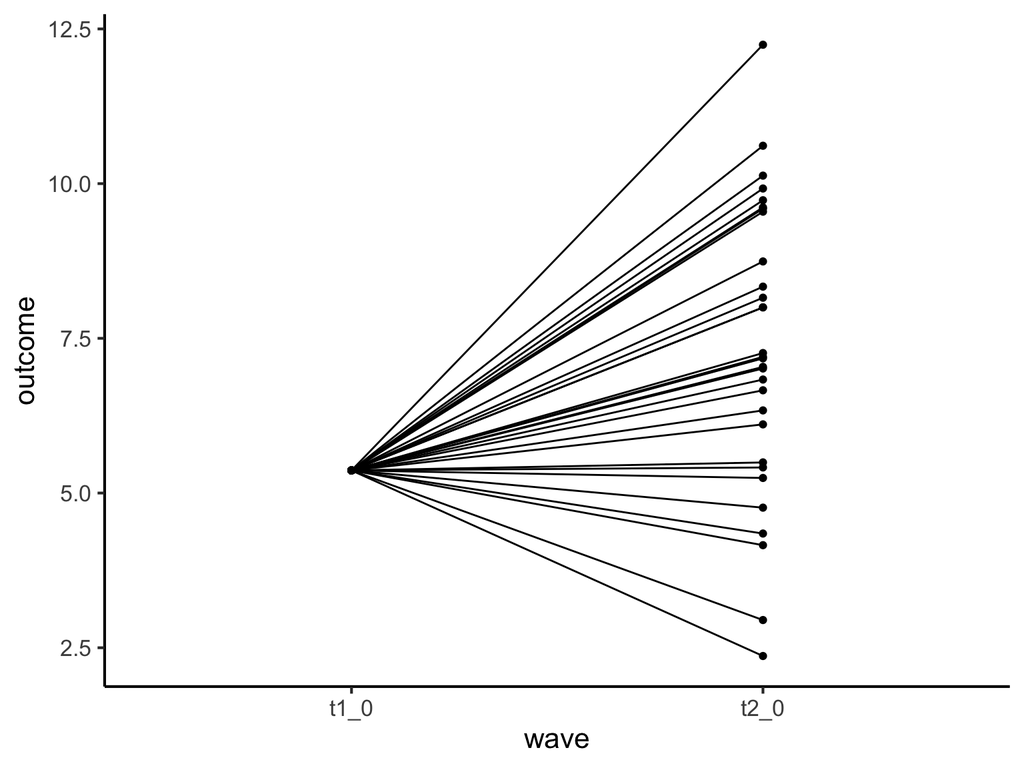

# 4.3.7 Assessing stability on multiple variables

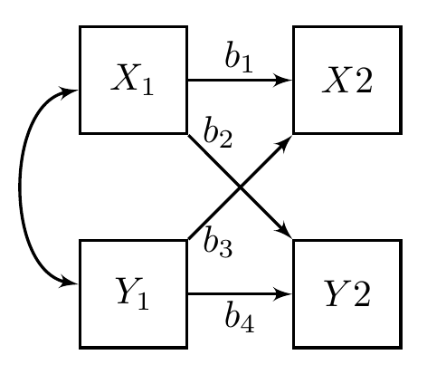

# 5 Comparisons and shortcomings

# 5.1 Does it matter?

# 5.1.1 Difference, partial change, or ANCOVA?

You have 2 waves of data and want to analyze them

1. Which method should you use?
- Difference score, partial change score, or ANCOVA?
2. Does it matter which one you use?
- Are the conclusions the same or not?

# 5.1.2 It matters - sometimes

In certain **common** situations, difference score, partial change score, and ANCOVA methods produce different results (i.e., different conclusions)

**Lord’s Paradox**: Lord (1967, 1969, 1973)  
Pretest-posttest designs with *non-randomized* groups  
Difference score does not show significant change  
ANCOVA does show significant change

”…there simply is no logical or statistical procedure that can be counted on to make proper allowances for uncontrolled pre-existing differences between groups.”

# 5.1.3 Really a paradox?

Not really

These methods are asking slightly different questions

- Makes sense that they could produce different results

See Lord (1967), Pike (2004), Tu et al. (2008) for more discussion

# 5.2 Difference and partial change score (UN)reliability

# 5.2.1 Unreliability of a difference?

Reliability of a variable is a quantitative measure of consistency

Usually, we want reliability of at least 0.8

There is *some evidence* that difference scores have poor reliability (Lord, 1956), even when the scores that go into the difference have good reliability

Situations where this happens are very **common** in practice

# 5.2.2 Reliability of a difference?

However, there are situations in which difference scores show good reliability (Rogosa et al., 1982 and Rogosa & Willett, 1983)

Situations where this happens are very **uncommon** in practice

# 5.3 What are these methods doing?

# 5.3.1 Definition of change

The definition of “change” is different for the models

**Difference score** (and partial change score)

- Absolute amount of change in $Y$
- i.e., 5 unit change is 5 unit change, regardless of where you started

**ANCOVA**

- Change in rank ordering
- Specifically, are you higher or lower at time 2, assuming everyone is the same at time 1?

# 5.3.2 Implied relationship between $Y_1$ and $Y_2$

**Difference score**

- Implies a **perfect** relationship between $Y_1$ and $Y_2$
- Not perfect: model overadjusts, leading to NS results

**Partial change score**

- Estimates the relationship between $Y_1$ and $Y_2$
- And **removes** it

**ANCOVA**

- Estimates the relationship between $Y_1$ and $Y_2$
- And **partials** it out

# 5.3.3 Individual versus relative change

**Difference score** (and partial change score)

- Individual change
- Each subject has their own “change score”

**ANCOVA**

- Relative rank
- Relative change, assuming everyone is the same at pre-test

# 5.4 When should you use each method?

# 5.4.1 What is your research question?

Do you want to rule out the possibility of **pre-test differences** producing your effect?

- Use ANCOVA
  - Difference scores don’t account for baseline / time 1 differences
- But keep in mind that ANCOVA is equating everyone at time 1
  - Is that realistic? Does that make sense in your situation?

# 5.4.2 Is equating realistic?

Often not realistic:

- Non-randomized groups: gender, race, self-selected treatments
  - Especially when the groups do not, by nature, overlap or have similar means on the outcome

Could be realistic:

- Randomized groups that have different pre-test means (by chance)
- Non-randomized groups that have similar means or have been matched

# 5.4.3 What is your research question?

Are you interested in the **specific, individual amount of change**?

- Use difference scores
  - ANCOVA tells you about relative change
- Partial change scores are a good choice too
  - Individual change but also *remove* time 1 differences

# 5.4.4 Conclusions

Difference score models work well if there are **few pre-test differences** and you are interested in **individual level of change** from one timepoint to another

ANCOVA models work well if you have **pre-test differences** that make sense to equate across groups  
They focus on **relative changes** in rank from one timepoint to another

Partial change scores are kind of in the middle and can help you answer questions that don’t quite fit difference score or ANCOVA approaches